# ATHK1001 Evidence tutorial

week of 30 April, 2018

### Learning Outcomes

Understand the following:

Explanatory variable Confound or confounding variable Controlled variable

An explanatory variable is one that may explain differences in a dependent variable (DV). For example, a predictor variable in regression analysis is an explanatory variable.

### Study elements

[output not shown]

As you go through the examples below, fill out the three right columns of the table.

[figure not shown]

The boy in the cartoon has noticed a correlation. According to the line of thinking articulated by the boy, what might be the dependent variable? _______________________________

What is the explanatory variable, in his line of thinking? _______________________________

Like any correlation between one variable (X) and another (Y), there are three possible explanations:

1. X causes Y
2. Y causes X
3. A third factor is involved.

Which explanation is most plausible? _______________________________

Under the third-factor explanation, what could the third factor be and what might its relationship to the others?

._________________________________________________________________  
________________________________________________________________

As shown in the graph below, over the year, murder rates and ice cream sales are highly positively correlated. That is, days with higher murder rates also have higher sales of ice cream.

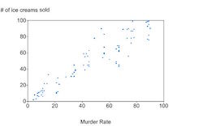

Like any correlation between one variable (X) and another (Y), there are three possible explanations:

1. X causes Y
2. Y causes X
3. A third factor is involved.

Which explanation is most plausible? _______________________________

Under the third-factor explanation, what could the third factor be and what might its relationship to the others?

._________________________________________________________________  
________________________________________________________________

How could we test this explanation? ________________________________________________________________

________________________________________________________________

Can you think of any way, even if implausible, that murder rate could cause ice cream sales or vice versa?

________________________________________________________________

________________________________________________________________

**Confound**: Consider a relationship between two variables, X and Y, with higher levels of X associated with higher level of Y. A confounding variable is an extraneous variable that is statistically related to (or correlated with) the X. This means that as X changes, the confounding variable changes along with it. Above, the confounds came up when you were asked about a **third factor** (not all third factors are confounds).

### Correlation and causation

For the school science fair, a year 6 student is interested in the effect of ultraviolet (UV) light on plant growth.

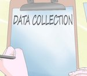

She gets a packet of pea plant seeds and distributes them randomly among fifty pots. She puts twenty-five of the pots under an ultraviolet light (a heat lamp) and twenty-five under a broad-spectrum halogen bulb, and a month later finds that all twenty-five of the ultraviolet pots’ plants are higher.

What is the dependent variable? ____________________________

What is the explanatory variable? ____________________________

Is this study an experiment or a correlational study? ____________________________

Can you think of any third factor that might explain the difference in plant height? ______________________

In perfect experiments, there is no variable that systematically changes with the explanatory variable besides the explanatory variable (and its effects) itself. This is why experiments provide the most secure way to determine whether an explanatory variable is truly affecting the dependent variable.

The explanatory variable in an experiment is called the **independent variable**, because if the experiment is done perfectly, there is no confounding variable that changes with it.

While an ideal experiment will not have a confound, there may still be third factors, e.g. the seeds that happened to end up in the UV light pots may have been stronger in some way. This is why statistics (p-values) should be calculated, to assess whether the difference in height could have occurred due to random factors.

#### For A groups to discuss

A lecturer finds that online self-quiz completion rate is highly positively correlated with final exam mark.

On the basis of this evidence, the lecturer says to the students, “You should complete the self-quiz because it will significantly improve your chances of getting a good exam grade.”

Describe a plausible alternative explanation of the evidence _____________________________________________________________________________________________________

On your alternative explanation, what causes what? ____________________________________________________  
How might you determine which theory is correct?

._____________________________________________________________________________________________________

_____________________________________________________________________________________________________

If you have time remaining, try to conceive of a *second* alternative explanation.  
._____________________________________________________________________________________________________

#### For B groups to discuss

Students in the Sydney University Liberal Club compare their course marks to the students of Sydney University’s Dark Alternative Society and a t-test indicates that the Liberals get significantly higher marks.

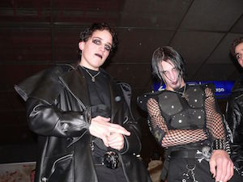

Goths (Wikimedia)

The Liberals conclude that they work harder than the Dark Alternatives, are smarter than them, or both.

Describe a plausible alternative explanation of the evidence ____________________________________________________

On your alternative explanation, what causes what? ____________________________________________________  
How might you determine which theory is correct?

-________________________________________________

____________________________________________________

### Finding things out, with Facts, Stats, Logic, and Science

You will see several statements. For each, write down:

1. What kind of evidence would be relevant to evaluate each claim.
2. Whether it’s a correlational study or an experiment that you’re thinking of, write down two specific variables you’d examine the link between.
3. Major confounds likely to be involved, if any?
4. What can be done to address the confounds?
5. An experiment to address the issue (even if practically impossible to conduct).
6. Whether the above experiment is possible and feasible or impossible.

Divide into groups, each group getting one or two of the below. Describe the kind of evidence that would be relevant to the numbered statements below (p.91 of Fundamentals of Critical Thinking has similar material).

1. Background: The police give more tickets to drivers of red cars. Statement to evaluate: The reason is that red cars attract attention, so the police are more likely to notice a red car violating the law.
2. Humanities classes at the University of Sydney are marked more leniently than science classes.
3. Background: Male drivers have significantly more accidents than female drivers. As a result, insurance companies in many countries charge males more. Statement to evaluate: Males are worse drivers than females.

### Remember

- Experiment versus quasi-experiment versus simple correlation
- Quasi-experiments are sometimes referred to as natural experiments
- Only a controlled experiment can definitively establish causality